# Alternatives to the Ti/Ti2 pad in NIS Elements

The Ti2 pad can take up a lot of screen are in NIS-Elements, and users generally only use it to select the objective and turn on the perfect focus system. Here we show an alternative that provides more useful information to the user, and takes up less screen space.

Mark Rigby (Nikon Insturments UK)https://www.microscope.healthcare.nikon.com/  
2020-06-15

The Ti2 pad has alot of information. The user has full control over the microscope and can select objectives, filter cubes, shutters, light path, diascopic light intensity, among many more features. However, typically users will encode the majority of this information within an optical configuration (OC), and not interact with the Ti2 pad during their experiments, except perhaps to change the objective.

[figure not shown]

Figure 1: The Ti2 pad occupying a large amount of precious screen space

It is not possible to remove controls from the Ti2 pad without reducing functionality, and so this post provides an alternative solution, which uses the macro panel as an objective selector, and the system information pad to provide information on the XYZ position of the stafe, perfect focus system offset, amongst additional readouts, whilst saving significant screen space.

[figure not shown]

Figure 2: Macro panel allows users to select objectives, and system information panel gives control over the PFS as well as a showing the z position plotted against time

To change to the later setup, firstly, set up the macro panel to execute commands that change the nosepiece position. Screenshots from the Ti2 pad objectives can be taken and associated with the relevant macro button.

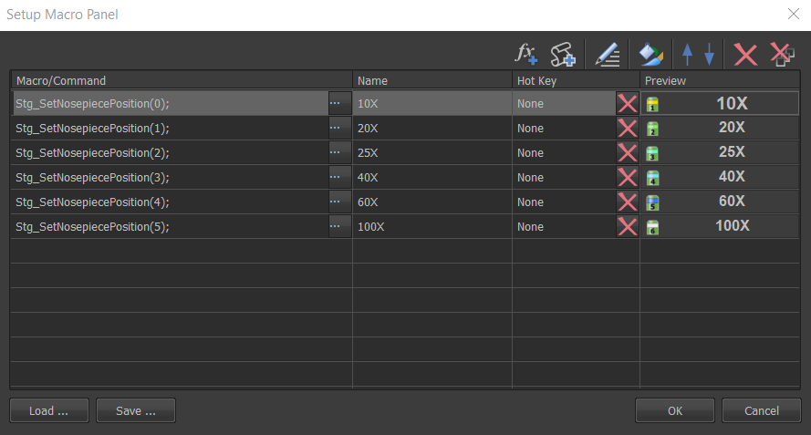

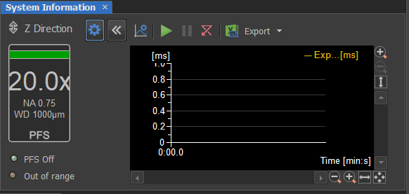